# Allometries and conversions

Lauren Buckley and the TrEnCh project, Department of Biology, University of Washington

2022-04-14

```r
##Load TrenchR package
library(TrenchR)
```

This tutorial reviews tools that use allometries to estimate the dimensions of organisms needed for energy balances and other analyses. The tutorial also documents convenience functions for converting units. Finally, we present functions that describe thermal performance curves.

# Allometries

We provide tools for estimating additional dimensions of organisms from measured dimensions.

### Mass

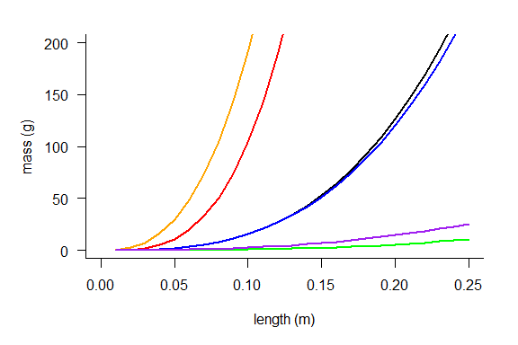

```r
par(mar = c(5, 5, 2, 2))
plot(x    = seq(0.01, 0.25, 0.01),
     y    = mass_from_length(l     = seq(0.01, 0.25, 0.01),
                             taxon = "lizard"),
     type = "l",
     xlab = "length (m)",
     ylab = "mass (g)",
     ylim = c(0, 200),
     xlim = c(0, 0.25),
     las  = 1,
     bty  = "L",
     lwd  = 2)
points(x    = seq(0.01, 0.25, 0.01),
       y    = mass_from_length(l     = seq(0.01, 0.25, 0.01),
                               taxon = "salamander"),
       type = "l",
       col  = "blue",
       lwd  = 2)

points(x    = seq(0.01, 0.25, 0.01),
       y    = mass_from_length(l     = seq(0.01, 0.25, 0.01),
                               taxon = "frog"),
       type = "l",
       col  = "red",
       lwd  = 2)
points(x    = seq(0.01, 0.25, 0.01),
       y    = mass_from_length(l     = seq(0.01, 0.25, 0.01),
                               taxon = "snake"),
       type = "l",
       col  = "green",
       lwd  = 2)
points(x    = seq(0.01, 0.25, 0.01),
       y    = mass_from_length(l     = seq(0.01, 0.25, 0.01),
                               taxon = "turtle"),
       type = "l",
       col  = "orange",
       lwd  = 2)
points(x    = seq(0.01, 0.25, 0.01),
       y    = mass_from_length(l     = seq(0.01, 0.25, 0.01),
                               taxon = "insect"),
       type = "l",
       col  = "purple",
       lwd  = 2)
```

### Surface Area

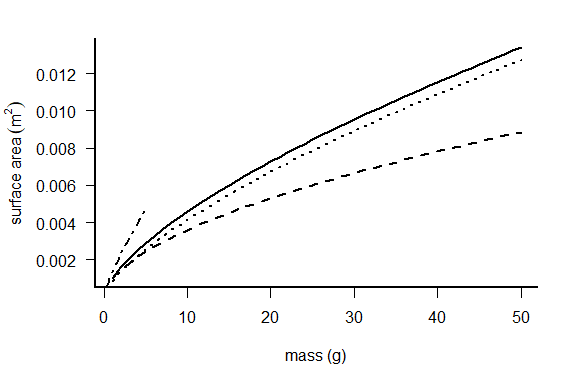

```r
par(mar = c(5, 5, 2, 2))

plot(x    = 1:50,
     y    = surface_area_from_mass(m     = 1:50,
                                   taxon = "lizard"),
     type = "l",
     xlab = "mass (g)",
     ylab = "",
     las  = 1,
     bty  = "L",
     lwd  = 2)
mtext(expression("surface area" ~ (m^{2})), 2, line = 3.5)
points(x    = 1:50,
       y    = surface_area_from_mass(m     = 1:50,
                                     taxon = "frog"),
       type = "l",
       lty  = "dashed",
       lwd  = 2)
points(x    = 1:50,
       y    = surface_area_from_mass(m     = 1:50,
                                     taxon = "salamander"),
       type = "l",
       lty  = "dotted",
       lwd  = 2)
points(x    = seq(0.1, 5, 0.2),
       y    = surface_area_from_mass(m     = seq(0.1,5,0.2),
                                     taxon = "insect"),
       type = "l",
       lty  = "dotdash",
       lwd   = 2)
box(bty = "L",
    lwd = 2)
```

We also provide empirical relationships estimating surface area as power law function of volume. The functions were developed by Mitchell (1976) for use in approximating convective heat transfer:

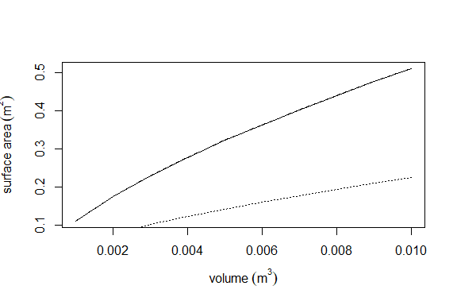

```r
plot(x    = seq(0.001, 0.01, 0.001),
     y    = surface_area_from_volume(V     = seq(0.001, 0.01, 0.001),
                                     taxon = "lizard"),
     type = "l",
     xlab = expression(volume ~ (m^{3})),
     ylab = expression("surface area" ~ (m^{2})))
points(x    = seq(0.001, 0.01, 0.001),
       y    = surface_area_from_volume(V     = seq(0.001, 0.01, 0.001),
                                       taxon = "frog"),
       type = "l",
       lty  = "dashed")
points(x    = seq(0.001, 0.01, 0.001),
       y    = surface_area_from_volume(V     = seq(0.001, 0.01, 0.001),
                                       taxon = "sphere"),
       type = "l",
       lty  = "dotted")
```

For the same study, we additionally provide a function to estimate volume from length for several taxa or by approximating the organism as a sphere. Finally, we provide a function for estimating surface area from length by approximating the animal’s body as a rotational ellipsoid. The allometric functions are available in R as follows:

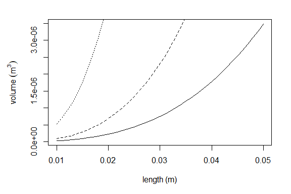

```r
par(mar = c(5, 5, 2, 2))

plot(x    = seq(0.01, 0.05, 0.001),
     y    = volume_from_length(l     = seq(0.01, 0.05, 0.001),
                               taxon = "lizard"),
     type = "l",
     xlab = "length (m)",
     ylab = expression(volume ~ (m^{3})))
points(x    = seq(0.01, 0.05, 0.001),
       y    = volume_from_length(l     = seq(0.01, 0.05, 0.001),
                                 taxon = "frog"),
       type = "l",
       lty  = "dashed")
points(x    = seq(0.01, 0.05, 0.001),
       y    = volume_from_length(l     = seq(0.01, 0.05, 0.001),
                                 taxon = "sphere"),
       type = "l",
       lty  = "dotted")
```

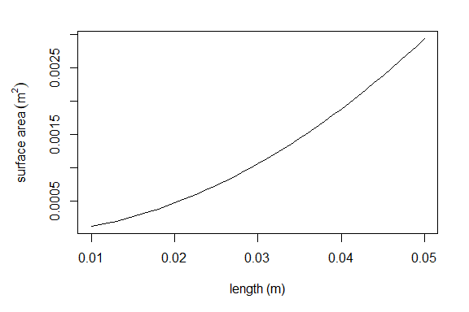

```r
par(mar = c(5, 5, 2, 2))

plot(x    = seq(0.01, 0.05, 0.001),
     y    = surface_area_from_length(l = seq(0.01, 0.05, 0.001)),
     type = "l",
     xlab = "length (m)",
     ylab = expression("surface area" ~ (m^{2})))
```

Estimating the amount of solar radiation that an animal absorbs requires knowledge of the silhouette area, the proportion of an animal’s surface area that is projected onto a horizontal surface. Silhouette area is a function of the sun’s angle. We offer empirically-derived relationships to predict the proportional silhouette area for frogs, lizards, and grasshoppers as a polynomial function of zenith angle (`proportion_silhouette_area()`). We additionally offer a function (`proportion_silhouette_area_shapes()`) to estimate silhouette area by approximating the animal as a sphere or cylinder. The R functions are parameterized as follows:

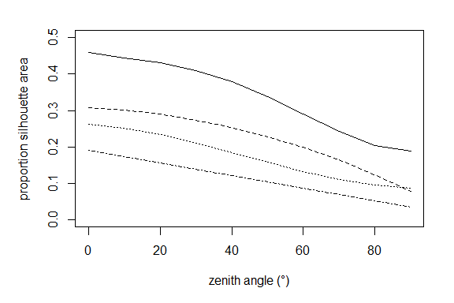

```r
par(mar = c(5, 5, 2, 2))

plot(x    = seq(0, 90, 10),
     y    = proportion_silhouette_area(z     = seq(0, 90, 10),
                                       taxon = "frog"),
     type = "l",
     xlab = "zenith angle (°)",
     ylab = "proportion silhouette area",
     ylim = range(0,0.5))
points(x    = seq(0, 90, 10),
       y    = proportion_silhouette_area(z       = seq(0, 90, 10),
                                         taxon   = "lizard",
                                         raz     = 0,
                                         posture = "prostrate"),
       type = "l",
       lty  = "dashed")
points(x    = seq(0, 90, 10),
       y    = proportion_silhouette_area(z       = seq(0, 90, 10),
                                         taxon   = "lizard",
                                         raz     = 0,
                                         posture = "elevated"),
       type = "l",
       lty  = "dotted")
points(x    = seq(0, 90, 10),
       y    = proportion_silhouette_area(z     = seq(0, 90, 10),
                                         taxon =  "grasshopper"),
       type = "l",
       lty  = "dotdash")
```

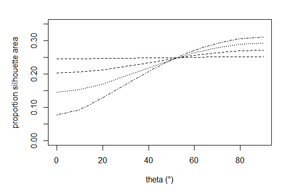

```r
plot(x    = seq(0, 90, 10),
     y    = proportion_silhouette_area_shapes(shape = "spheroid",
                                              theta = seq(0, 90, 10),
                                              h     = 0.4,
                                              d     = 0.39),
     type = "l",
     xlab = "theta (°)",
     ylab = "proportion silhouette area",
     ylim = c(0,0.35),
     lty  = "dashed")
points(x    = seq(0, 90, 10),
       y    = proportion_silhouette_area_shapes(shape = "spheroid",
                                                theta = seq(0, 90, 10),
                                                h     = 0.4,
                                                d     = 0.3),
       type = "l",
       lty  = "dashed")
points(x    = seq(0, 90, 10),
       y    = proportion_silhouette_area_shapes(shape = "spheroid",
                                                theta = seq(0, 90, 10),
                                                h     = 0.4,
                                                d     = 0.2),
       type = "l",
       lty  = "dotted")
points(x    = seq(0, 90, 10),
       y    = proportion_silhouette_area_shapes(shape = "spheroid",
                                                theta = seq(0, 90, 10),
                                                h     = 0.4,
                                                d     = 0.1),
       type = "l",
       lty  = "dotdash")
```

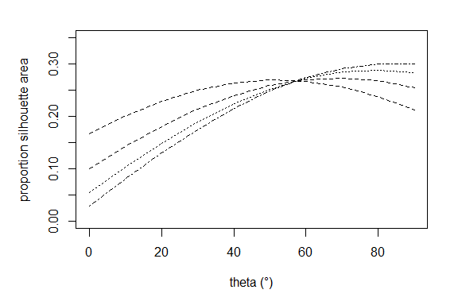

```r
plot(x    = seq(0, 90, 10),
     y    = proportion_silhouette_area_shapes(shape = "cylinder flat ends",
                                              theta = seq(0, 90, 10),
                                              h     = 0.4,
                                              d     = 0.4),
     type = "l",
     lty  = "dashed",
     xlab = "theta (°)",
     ylab = "proportion silhouette area",
     ylim = c(0,0.35))
points(x    = seq(0, 90, 10),
       y    = proportion_silhouette_area_shapes(shape = "cylinder flat ends",
                                                theta = seq(0, 90, 10),
                                                h     = 0.4,
                                                d     = 0.2),
       type = "l",
       lty  = "dashed")
points(x    = seq(0, 90, 10),
       y    = proportion_silhouette_area_shapes(shape = "cylinder flat ends",
                                                theta = seq(0, 90, 10),
                                                h     = 0.4,
                                                d     = 0.1),
       type = "l",
       lty  = "dotted")
points(x    = seq(0, 90, 10),
       y    = proportion_silhouette_area_shapes(shape = "cylinder flat ends",
                                                theta = seq(0, 90, 10),
                                                h     = 0.4,
                                                d     = 0.05),
       type = "l",
       lty  = "dotdash")
```

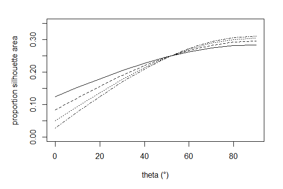

```r
plot(x    = seq(0, 90, 10),
     y    = proportion_silhouette_area_shapes(shape = "cylinder hemisphere ends",
                                              theta = seq(0, 90, 10),
                                              h     = 0.4,
                                              d     = 0.4),
     type = "l",
     xlab = "theta (°)",
     ylab = "proportion silhouette area",
     ylim = c(0,0.35))
points(x    = seq(0, 90, 10),
       y    = proportion_silhouette_area_shapes(shape = "cylinder hemisphere ends",
                                                theta = seq(0, 90, 10),
                                                h     = 0.4,
                                                d     = 0.2),
       type = "l",
       lty  = "dashed")
points(x    = seq(0, 90, 10),
       y    = proportion_silhouette_area_shapes(shape = "cylinder hemisphere ends",
                                                theta = seq(0, 90, 10),
                                                h     = 0.4,
                                                d     = 0.1),
       type = "l",
       lty  = "dotted")
points(x    = seq(0, 90, 10),
       y    = proportion_silhouette_area_shapes(shape = "cylinder hemisphere ends",
                                                theta = seq(0, 90, 10),
                                                h     = 0.4,
                                                d     = 0.05),
       type = "l",
       lty  = "dotdash")
```

# Conversions

We offer convenience functions to convert among units for angles and temperatures:

```r
degrees_to_radians(47.608)
```

```
## [1] 0.8309164
```

```r
radians_to_degrees(0.831)
```

```
## [1] 47.61279
```

```r
fahrenheit_to_celsius(85)
```

```
## [1] 29.44444
```

```r
fahrenheit_to_kelvin(85)
```

```
## [1] 302.5944
```

```r
kelvin_to_celsius(270)
```

```
## [1] -3.15
```

# Thermal Performance Curve Functions

Thermal performance curves (TPCs) describe the temperature dependence of organismal performance such as locomotion and digestion (Huey and Kingsolver 1989). They have become an important tool to understand organismal responses to environmental conditions, particularly responses to climate change (Sinclair et al. 2016). TrenchR includes two forms of TPCs. We include a function `TPC()` to describe a Gaussian-quadratic TPC as a function of thermal optima and critical thermal minima and maxima (Deutsch et al. 2008). The `TPC.beta()` function uses a beta function to define a TPC based on mode, breadth, and skew. A scale factor enables including a thermodynamic effect on mean performance (Asbury and Angilletta Jr 2010).

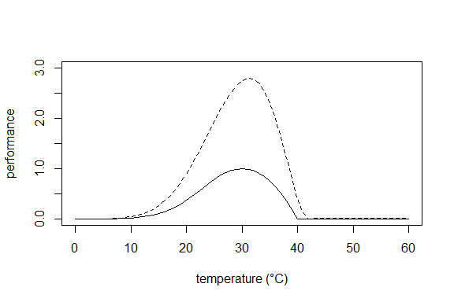

```r
plot(x    = 0:60,
     y    = TPC(T      = 0:60,
                T_opt  = 30,
                CT_min = 10,
                CT_max = 40),
     type = "l",
     ylim = c(0,3),
     ylab = "performance",
     xlab = "temperature (°C)")
points(x    = 0:60,
       y    = TPC.beta(T         = 0:60,
                       shift     = -1,
                       breadth   = 0.1,
                       aran      = 0,
                       tolerance = 43,
                       skew      = 0.7),
       type = "l",
       lty  = "dashed")
```

# References

Asbury, D. A., and M. J. Angilletta Jr. 2010. “Thermodynamic Effects on the Evolution of Performance Curves.” *The American Naturalist* 176 (2): E40–49.

Deutsch, C. A., J. J. Tewksbury, R. B. Huey, K. S. Sheldon, C. K. Ghalambor, D. C. Haak, and P. R. Martin. 2008. “Impacts of Climate Warming on Terrestrial Ectotherms Across Latitude.” *Proceedings of the National Academy of Sciences* 105 (18): 6668–72.

Huey, R. B., and J. G. Kingsolver. 1989. “Evolution of Thermal Sensitivity of Ectotherm Performance.” *Trends in Ecology & Evolution* 4 (5): 131–35.

Mitchell, John W. 1976. “Heat Transfer from Spheres and Other Animal Forms.” *Biophysical Journal* 16 (6): 561–69.

Sinclair, B. J., K. E. Marshall, M. A. Sewell, D. L. Levesque, C. S. Willett, S. Slotsbo, Y. Dong, et al. 2016. “Can We Predict Ectotherm Responses to Climate Change Using Thermal Performance Curves and Body Temperatures?” *Ecology Letters* 19 (11): 1372–85.